# Math-Practical-Major-6th-sem

```
(* Settings *)
SetOptions[
    Plot,
    Background -> White,
    AxesStyle -> Black,
    LabelStyle -> Black,
    TicksStyle -> Black
];

SetOptions[
    Plot3D,
    Background -> White,
    BoxStyle -> Black,
    AxesStyle -> Black,
    LabelStyle -> Black,
    TicksStyle -> Black
];

SetOptions[
    ParametricPlot,
    Background -> White,
    AxesStyle -> Black,
    LabelStyle -> Black,
    TicksStyle -> Black
];
```

Practical-1

Solution of Cauchy problem for First-Order Partial Differential Equation (PDE)

Problem-1: To obtain the solution of the linear equation
$$ u_x - u_y = 1 $$ with the Cauchy data $ u(x, 0) = x^2 $

Solution:

```
Clear[x, y, u, t,
    pde, initialCondition,
    solution,
    surface, initialCurve
]

pde = D[u[x, y], x] - D[u[x, y], y] == 1

initialCondition = u[x, 0] == x^2;

solution = DSolve[{pde, initialCondition}, u[x, y], {x, y}]

surface = Plot3D[
    u[x, y] /. solution, {x, -4, 4}, {y, -5, 5},
    AxesLabel -> {"x", "y", "u"},
    PlotLabel -> "Integral surface through initial curve",
    ColorFunction -> (ColorData["BlueGreenYellow"][1 - #3] &),
    ColorFunctionScaling -> True
];

initialCurve = ParametricPlot3D[
    {t, 0, t^2}, {t, -4, 4},
    PlotStyle -> {Thick, Red}
];

Show[surface, initialCurve]
```

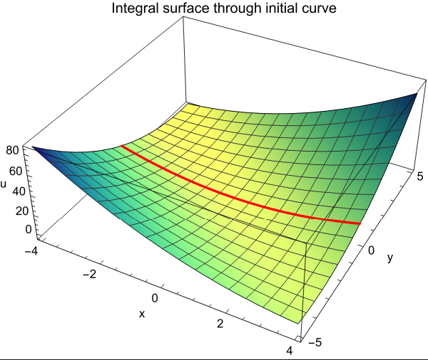

Result: The solution of the Cauchy problem for the given PDE is obtained in the output and visualized as an integral surface.

Problem-2: To obtain the solution of the linear equation
$$ u(x + y)\,u_x + u(x - y)\,u_y = x^2 + y^2 $$ with the Cauchy data $ u(x, 2x) = 0 $

Solution:

```
Clear[x, y, u, t,
    pde, initialCondition,
    solution,
    surface, initialCurve
]

pde = u[x, y] (x + y) D[u[x, y], x] + u[x, y] (x - y) D[u[x, y], y] == x^2 + y^2

initialCondition = u[x, 2 x] == 0;

solution = DSolve[{pde, initialCondition}, u[x, y], {x, y}]

surface = Plot3D[
    u[x, y] /. solution, {x, -4, 4}, {y, -5, 5},
    AxesLabel -> {"x", "y", "u"},
    PlotLabel -> "Integral surface through initial curve",
    ColorFunction -> (ColorData["DeepSeaColors"]),
    ColorFunctionScaling -> True
];

initialCurve = ParametricPlot3D[
    {t, 2*t, 0}, {t, -4, 4},
    PlotStyle -> {Thick, Red}
];

Show[surface, initialCurve]
```

[figure not shown]

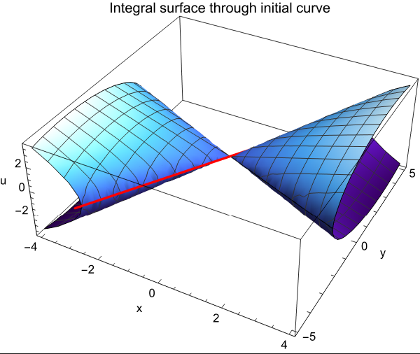

Result: The solution of the Cauchy problem for the given PDE is obtained in the output and visualized as an integral surface.

Problem-3: To obtain the solution of the linear equation
$$ u_x + u_y = u^2 $$ (a) with the Cauchy data $ x + y = 0 $, $ u = 1 $
(b) with the Cauchy data $ u(x, 0) = \tanh{(x)} $

Solution:

(a)

```
Clear[x, y, u, t,
    pde, initialCondition,
    solution,
    surface, initialCurve
]

pde = D[u[x, y], x] + D[u[x, y], y] == (u[x, y])^2

(* x + y = 0, u = 1 => y = -x, u = 1 => u[x, -x] = 1 *)
initialCondition = u[x, -x] == 1;

solution = DSolve[{pde, initialCondition}, u[x, y], {x, y}]

surface = Plot3D[
    u[x, y] /. solution, {x, -10, 10}, {y, -10, 10},
    AxesLabel -> {"x", "y", "u"},
    PlotLabel -> "Integral surface through initial curve",
    PlotStyle -> Cyan
];

initialCurve = ParametricPlot3D[
    {t, -t, 1}, {t, -10, 10},
    PlotStyle -> {Thick, Red}
];

Show[surface, initialCurve]
```

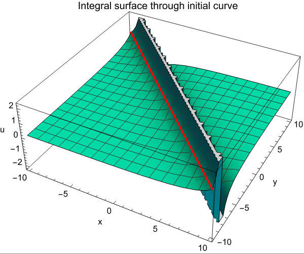

(b)

```
Clear[x, y, u, t,
    pde, initialCondition,
    solution,
    surface, initialCurve
]

pde = D[u[x, y], x] + D[u[x, y], y] == (u[x, y])^2

initialCondition = u[x, 0] == Tanh[x];

solution = DSolve[{pde, initialCondition}, u[x, y], {x, y}]

surface = Plot3D[
    u[x, y] /. solution, {x, -10, 10}, {y, -10, 10},
    AxesLabel -> {"x", "y", "u"},
    PlotLabel -> "Integral surface through initial curve",
    ColorFunction -> (ColorData["DeepSeaColors"]),
    ColorFunctionScaling -> True
];

initialCurve = ParametricPlot3D[
    {t, 0, Tanh[t]}, {t, -10, 10},
    PlotStyle -> {Thick, Red}
];

Show[surface, initialCurve]
```

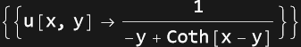

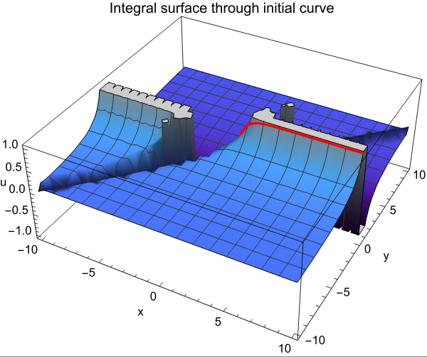

Result: The solution of the Cauchy problem for the given PDE is obtained in the output and visualized as an integral surface.

Practical-2

Plotting the Characteristics for the First-Order PDE

Problem-1: To find the characteristics of the equation
$$ \left (u - y \right )\,u_x + y \,u_y = x + y $$ and plot them.

Solution:

The auxiliary equations of the given PDE is
$$ \dfrac{dx}{u - y} = \dfrac{dy}{y} = \dfrac{du}{x + y} \tag{1} $$ We have,
$$ \Rightarrow \dfrac{dx + du}{(u - y) + (x + y)} = \dfrac{dy}{y} $$ $$ \Rightarrow \dfrac{d(x + u)}{x + u} = \dfrac{dy}{y} $$ $$ \Rightarrow \int \dfrac{d(x + u)}{x + u} = \int \dfrac{dy}{y} $$ $$ \Rightarrow \log{(x + u)} = \log{(y)} + \log{(c_1)} $$ $$ \Rightarrow \dfrac{x + u}{y} = c_1 $$ $$ \therefore\; u = c_1\,y - x \tag{2} $$ Here, $ c_1 $ is a constant.
Again, we have from Eq.(1), $$ \Rightarrow \dfrac{dx + dy}{(u - y) + y} = \dfrac{du}{x+y} $$ $$ \Rightarrow \dfrac{d(x + y)}{u} = \dfrac{du}{x+y} $$ $$ \Rightarrow (x+y)\,d(x+y) = u\,du $$ $$ \Rightarrow \int (x+y)\,d(x+y) = \int u\,du $$ $$ \Rightarrow \dfrac{(x+y)^2}{2} = \dfrac{u^2}{2} + \dfrac{c_2}{2} $$ $$ \Rightarrow (x+y)^2 - u^2 = c_2 $$ $$ \therefore\; u = \sqrt{\left(x+y\right)^2 - c_2} \tag{3}$$
Here, $ c_2 $ is a constant.

```
Clear[f, h]

(* c = c1 = -10, 0, 10 *)
f = Table[
   Plot3D[c y - x, {x, -4, 4}, {y, -5, 5},
    AxesLabel -> {"x", "y", "u"},
    PlotLabel -> "Characteristics of Eq.(2) for c1 = -10, 0, 10",
    ColorFunction -> (Blend[{Blue, Cyan, Magenta}, #3] &),
    ColorFunctionScaling -> True
   ],
   {c, {-10, 0, 10}}
];

Show[f]

(* d = c2 = -10, 0, 10 *)
h = Table[
   Plot3D[Sqrt[(x + y)^2 - d], {x, -4, 4}, {y, -5, 5},
    AxesLabel -> {"x", "y", "u"},
    PlotLabel -> "Characteristics of Eq.(3) for c2 = -10, 0, 10",
    ColorFunction -> (ColorData["DeepSeaColors"][1 - #3] &),
    ColorFunctionScaling -> True
   ],
   {d, {-10, 0, 10}}
];

Show[h]
```

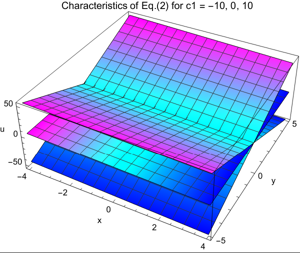

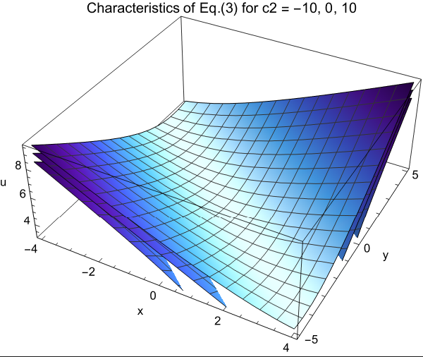

Result: The characteristics of the given PDE are plotted in the output.

Practical-3

Plotting the Integral Surfaces of a given First-Order PDE with Initial Data

Problem-1: To find the solution of the equation
$$ u_x + y\, u_y = 0 $$ with the Cauchy data $ u(0, y) = 4y $
Plot the integral surface with in the range $ (x, -4, 4) $ & $ (y, -5, 5) $

Solution:

```
Clear[x, y, u, t,
    pde, initialCondition,
    solution,
    surface, initialCurve
]

pde = D[u[x, y], x] + y D[u[x, y], y] == 0

initialCondition = u[0, y] == 4 y;

solution = DSolve[{pde, initialCondition}, u[x, y], {x, y}]

Plot3D[
    u[x, y] /. solution, {x, -4, 4}, {y, -5, 5},
    AxesLabel -> {"x", "y", "u"},
    PlotLabel -> "Integral surface",
    ColorFunction -> (Blend[{Blue, Magenta}, #3] &),
    ColorFunctionScaling -> True
]
```

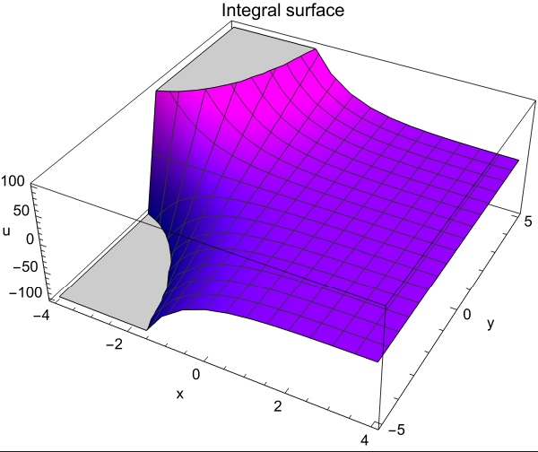

Result: The solution of the Cauchy problem for the given PDE is obtained in the output and visualized as an integral surface.

Problem-2: To obtain the solution of the equation
$$ u_x + u\, u_y = 1 $$ with the Cauchy data $ u(0, y) = 4y $
Plot the integral surface with in the range $ (x, -4, 4) $ & $ (y, -5, 5) $

Solution:

```
Clear[x, y, u, t,
    pde, initialCondition,
    solution,
    surface, initialCurve
]

pde = D[u[x, y], x] + u[x, y] D[u[x, y], y] == 1

initialCondition = u[0, y] == 4 y;

solution = DSolve[{pde, initialCondition}, u[x, y], {x, y}]

Plot3D[
    u[x, y] /. solution, {x, -4, 4}, {y, -5, 5},
    AxesLabel -> {"x", "y", "u"},
    PlotLabel -> "Integral surface",
    ColorFunction -> "AvocadoColors",
    ColorFunctionScaling -> True
]
```

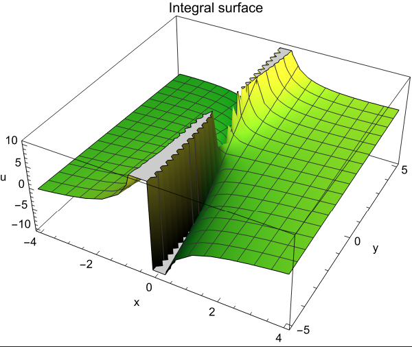

Result: The solution of the Cauchy problem for the given PDE is obtained in the output and visualized as an integral surface.

Problem-3: To obtain the solution of the equation
$$ u_x + u_y = 1 $$ with the Cauchy data $ u(x, 2x) = x^3 $
Plot the integral surface with in the range $ (x, -4, 4) $ & $ (y, -5, 5) $

Solution:

```
Clear[x, y, u, t,
    pde, initialCondition,
    solution,
    surface, initialCurve
]

pde = D[u[x, y], x] + D[u[x, y], y] == 1

initialCondition = u[x, 2 x] == x^3;

solution = DSolve[{pde, initialCondition}, u[x, y], {x, y}]

Plot3D[
    u[x, y] /. solution, {x, -4, 4}, {y, -5, 5},
    AxesLabel -> {"x", "y", "u"},
    PlotLabel -> "Integral surface",
    ColorFunction -> (ColorData["BlueGreenYellow"][#3] &),
    ColorFunctionScaling -> True
]
```

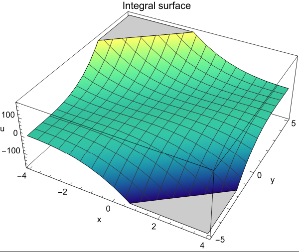

Result: The solution of the Cauchy problem for the given PDE is obtained in the output and visualized as an integral surface.

Practical-4

Solutions of Wave equation for associated conditions

$$ \dfrac{\partial^2 u}{\partial t^2} = c^2 \dfrac{\partial^2 u}{\partial x^2} $$

(a) $ u(x, 0) = \phi (x) $, $ u(x, 0) = \psi (x) $; $ x \in \mathbb{R} $, $ t > 0 $  
(b) $ u(x, 0) = \phi (x) $, $ u_t(x, 0) = \psi (x) $, $ u(0, t) = 0 $; $ x > 0 $, $ t > 0 $  
(c) $ u(x, 0) = \phi (x) $, $ u_t(x, 0) = \psi (x) $, $ u_x(0, t) = 0 $; $ x > 0 $, $ t > 0 $  
(d) $ u(x, 0) = \phi (x) $, $ u_t(x, 0) = \psi (x) $, $ u(0, t) = 0 $, $ u(l, t) = 0 $; $ x > 0 $, $ t > 0 $

Problem-1: To obtain the solution of the wave equation
$$ u_{tt} - u_{xx} = 0, \;\; 0 < x < 1,\;\; t > 0$$ for the initial conditions $$ u(x, 0) = \sin{(x)},\;\; u_t(x, 0) = \cos{(x)}, \;\; 0 \leq x \leq 1,\;\; t \geq 0$$

Solution:

```
Clear[x, t, u, pdeWithConditions, solution]

pdeWithConditions = {D[u[x, t], {t, 2}] - D[u[x, t], {x, 2}] == 0,
    u[x, 0] == Sin[x],
    Derivative[0, 1][u][x, 0] == Cos[x]
}

solution = NDSolve[pdeWithConditions, u[x, t], {x, 0, 1}, {t, 0, 4},
    PrecisionGoal -> 3
]

Plot3D[u[x, t] /. solution, {x, 0, 1}, {t, 0, 4},
    AxesLabel -> {"x", "t", "u"},
    PlotLabel -> "Solution surface of the given Wave equation",
    ColorFunction -> (Blend[{Orange, Magenta}, #3] &),
    ColorFunctionScaling -> True
]
```

```
NDSolve::bcart: Warning: an insufficient number of boundary conditions have been specified for the direction of independent variable x. Artificial boundary effects may be present in the solution.
```

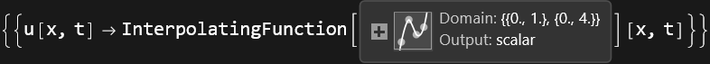

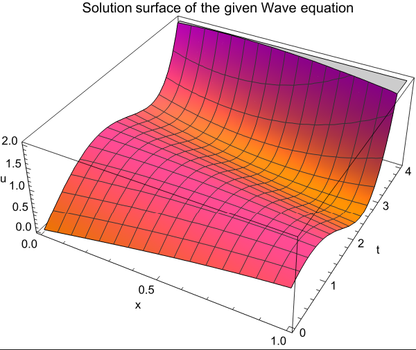

Result: The solution of the given Wave equation is obtained and visualized as a surface.

Problem-2: To obtain the solution of the wave equation
$$ u_{tt} - u_{xx} = -9.80665, \;\; 0 < x < 1,\;\; t > 0 $$ for the initial conditions $$ u(x, 0) = 10\,x^2\,(1 - x)^2,\;\; u_t(x, 0) = 0, \;\;u(0, t) = u(1, t) = 0, \;\; 0 \leq x \leq 1,\;\; t \geq 0$$

Solution:

```
Clear[x, t, u, pdeWithConditions, solution]

pdeWithConditions = {D[u[x, t], {t, 2}] - D[u[x, t], {x, 2}] == -9.80665,
    u[x, 0] == 10 x^2 (1 - x)^2,
    Derivative[0, 1][u][x, 0] == 0,
    u[0, t] == 0,
    u[1, t] == 0
}

solution = NDSolve[pdeWithConditions, u[x, t], {x, 0, 1}, {t, 0, 4},
    PrecisionGoal -> 3
]

Plot3D[u[x, t] /. solution, {x, 0, 1}, {t, 0, 4},
    AxesLabel -> {"x", "t", "u"},
    PlotLabel -> "Solution surface of the given Wave equation",
    ColorFunction -> (Blend[{Blue, Cyan, Magenta}, #3] &),
    ColorFunctionScaling -> True
]
```

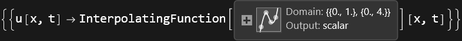

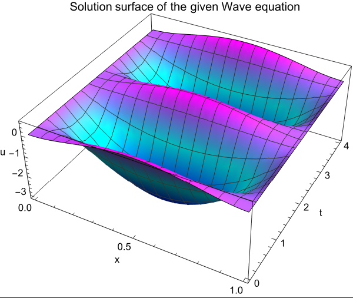

Result: The solution of the given Wave equation is obtained and visualized as a surface.

Problem-3: To obtain the solution of the wave equation
$$ u_{tt} - u_{xx} = 0, \;\; 0 < x < 2,\;\; t > 0 $$ for the initial conditions $$ u(x, 0) = \sin{\left(\dfrac{\pi x}{2} \right)} ,\;\; u_t(x, 0) = 0, \;\;u(0, t) = u(2, t) = 0, \;\; 0 \leq x \leq 2,\;\; t \geq 0$$

Solution:

```
Clear[x, t, u, pdeWithConditions, solution]

pdeWithConditions = {D[u[x, t], {t, 2}] - D[u[x, t], {x, 2}] == 0,
    u[x, 0] == Sin[(π x)/2],
    Derivative[0, 1][u][x, 0] == 0,
    u[0, t] == 0,
    u[2, t] == 0
}

solution = DSolve[pdeWithConditions, u[x, t], {x, t}
]

Plot3D[u[x, t] /. solution, {x, 0, 1}, {t, 0, 4},
    AxesLabel -> {"x", "t", "u"},
    PlotLabel -> "Solution surface of the given Wave equation",
    ColorFunction -> (Blend[{Blue, Cyan, Magenta}, #3] &),
    ColorFunctionScaling -> True
]
```

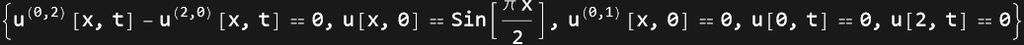

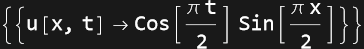

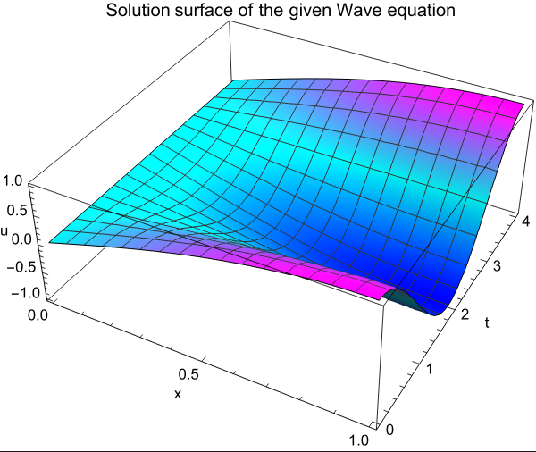

Result: The solution of the given Wave equation is obtained and visualized as a surface.

Problem-4: To obtain the solution of the wave equation
$$ u_{tt} - u_{xx} = 0, \;\; 0 < x < 1,\;\; t > 0 $$ for the initial conditions $$ u(x, 0) = \log{(1 + x^2)} ,\;\; u_t(x, 0) = 2, \;\; 0 \leq x \leq 1,\;\; t \geq 0 $$

Solution:

```
Clear[x, t, u, pdeWithConditions, solution]

pdeWithConditions = {D[u[x, t], {t, 2}] - D[u[x, t], {x, 2}] == 0,
    u[x, 0] == Log[1 + x^2],
    Derivative[0, 1][u][x, 0] == 2
}

solution = NDSolve[pdeWithConditions, u[x, t], {x, 0, 1}, {t, 0, 4},
    PrecisionGoal -> 3
]

Plot3D[u[x, t] /. solution, {x, 0, 1}, {t, 0, 4},
    AxesLabel -> {"x", "t", "u"},
    PlotLabel -> "Solution surface of the given Wave equation",
    ColorFunction -> (Blend[{Blue, Green}, #3] &),
    ColorFunctionScaling -> True
]
```

```
NDSolve::bcart: Warning: an insufficient number of boundary conditions have been specified for the direction of independent variable x. Artificial boundary effects may be present in the solution.
```

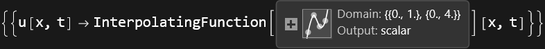

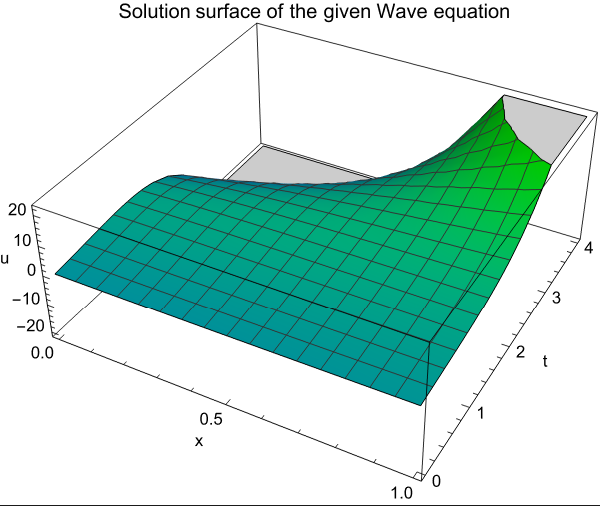

Result: The solution of the given Wave equation is obtained and visualized as a surface.

Practical-5

Solving systems of Ordinary Differential Equations (ODE)

Command: `DSolve[eqn, y[x], x]`  
solves a differential equation for `y[x]`  
Command: `DSolve[{eqn1, eqn2, eqn3, ...}, {y1[x], y2[x], y3[x], ...}, x]`  
solves a system of differential equation for `yi[x]` where $ i = 1, 2, 3, ... $

Linear Systems:
The general linear system of two first-order differential equations in two unknown functions $x$ and $y$ is of the form $$ a_1(t)\dfrac{dx}{dt} + a_2(t)\dfrac{dy}{dt} + a_3(t)\,x + a_4(t)\,y = F_1(t), $$ $$ b_1(t)\dfrac{dx}{dt} + b_2(t)\dfrac{dy}{dt} + b_3(t)\,x + b_4(t)\,y = F_2(t) \tag{1}$$ we shall say that a solution of system (1) is an ordered pair of real functions $(f, g)$ such that $ x = f(t),\; y = g(t) $ simultaneously satisfy both equations of system (1) on some real interval $ a \leq t \leq b $.

Problem-1: To solve the following system of ordinary differential equations
$$ \dfrac{dx}{dt} + \dfrac{dy}{dt} -x = -2t, $$ $$ \dfrac{dx}{dt} + \dfrac{dy}{dt} -3x = t^2 $$

Solution:

```
Clear[x, y, t,
    systems, solution, paricularSol]

systems = {
    x'[t] + y'[t] - x[t] == -2 t,
    x'[t] + y'[t] - 3 x[t] == t^2
}

solution = DSolve[systems, {x, y}, t]

particularSol = {x[t], y[t]} /. solution /. {C[1] -> 5}
Plot[Evaluate[particularSol], {t, -10, 10}]
```

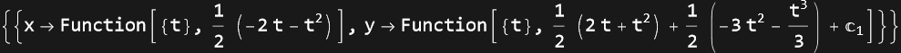

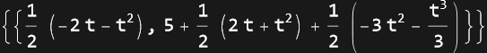

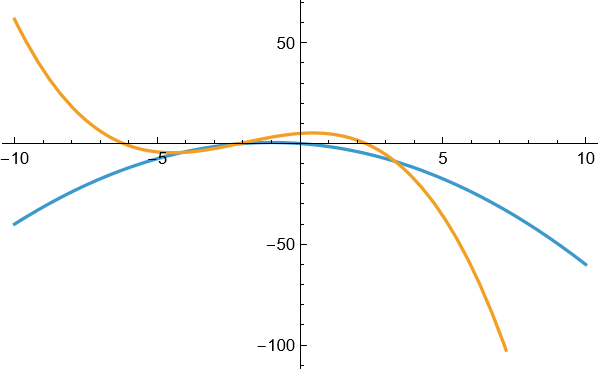

Result: The solution of the given system is obtained in the output and visualized as a graph.

Problem-2: To solve the following system of ordinary differential equations
$$ \dfrac{dx}{dt} + \dfrac{dy}{dt} + 4y = \sin{(t)} , $$ $$ \dfrac{dx}{dt} + \dfrac{dy}{dt} -x -y = 0 $$

Solution:

```
Clear[x, y, t,
    systems, solution, paricularSol]

systems = {
    x'[t] + y'[t] + 4 y[t] == Sin[t],
    x'[t] + y'[t] - x[t] - y[t] == 0
}

solution = DSolve[systems, {x, y}, t]

particularSol = {x[t], y[t]} /. solution /. {C[1] -> -1}
Plot[Evaluate[particularSol], {t, -10, 4}]
```

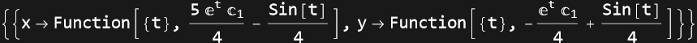

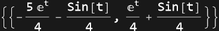

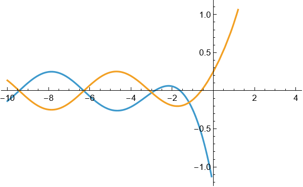

Result: The solution of the given system is obtained in the output and visualized as a graph.